# Chapter 7 notebook

# Exercises based on Vandermeer and Goldberg

**Due 16 April 2018**

### 6G

Plot a time series, phase plane, and describe the 4 nullclines for a predator-prey model where prey grow exponentially, the predation rate follows a Type II functional response, and predators die constantly (pgs. 164 and 165 from V&G). Use parameter values $r = 1.1$, $g = 1$, $c = 3$, and $m = 1$. Also, add a `trajectory()` line, starting near the interior equilibrium. What happens?

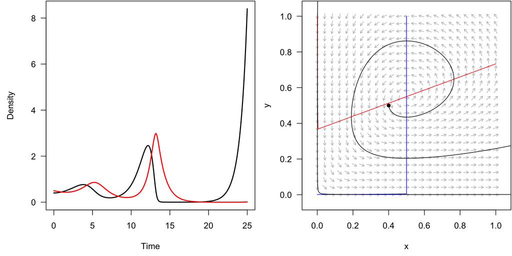

```r
TypeIIex <- function(t, y, parameters) {
  V <- y[1]
  P <- y[2]
  r <- parameters[1]
  g <- parameters[2]
  c <- parameters[3]
  m <- parameters[4]
  dV <- r*V - c*V*P/(g + V)
  dP <- c*V*P/(g + V) - m*P
  return(list(c(dV, dP)))
}

parms <- c(r = 1.1, g = 1, c = 3, m = 1)
int.6G <- c(0.4, 0.5)
time.6G <- seq(from = 0, to = 25, by = 0.1)

out.6G <- ode(y = int.6G, func = TypeIIex, parms = parms, times = time.6G)

par(mfrow = c(1, 2), mar = c(4.5, 4.5, 0.1, 0.1))
plot(x = out.6G[,1], out.6G[,2], las = 1, lwd = 2, xlab = "Time", ylab = "Density", type = "l")
  lines(x = out.6G[,1], out.6G[,3], lwd = 2, col = "red")

a <- flowField(deriv = TypeIIex, x.lim = c(0, 1), y.lim = c(0, 1), parameters = parms, add = F, points = 25, las = 1)
a <- nullclines(deriv = TypeIIex, x.lim = c(0, 1), y.lim = c(0, 1), parameters = parms, points = 200)
a <- trajectory(deriv = TypeIIex, parameters = parms, t.start = 0, t.end = max(time.6G), y = int.6G, pch = 16)
```

### 6H

Verbally describe the differences between the two.

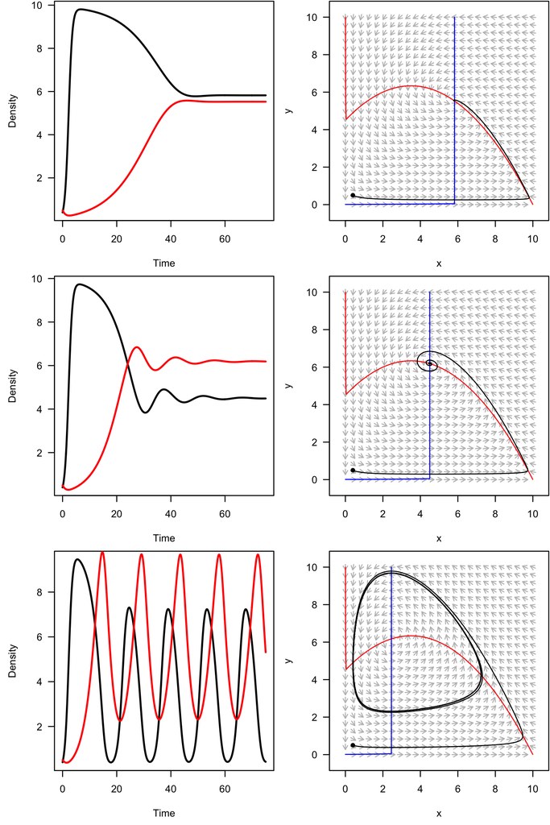

```r
par(mfrow = c(3, 2), mar = c(4.5, 4.5, 0.1, 0.1))

TypeIIlog_1 <- function(t, y, parameters) {
  V <- y[1]
  P <- y[2]
  r <- parameters[1]
  K <- parameters[2]
  g <- parameters[3]
  c <- parameters[4]
  m <- parameters[5]
  dV <- r*V*((K-V) / K) - c*V*P/(g + V)
  dP <- c*V*P/(g + V) - m*P
  return(list(c(dV, dP)))
}

parms_1 <- c(r = 1.5, K = 10, g = 3, c = 1, m = 0.66)
time_1 <- seq(from = 0, to = 75, by = 0.1)
int_1 <- c(0.4, 0.5)

out_1 <- ode(y = int_1, func = TypeIIlog_1, parms = parms_1, times = time_1)

plot(x = out_1[,1], out_1[,2], las = 1, lwd = 2, xlab = "Time", ylab = "Density", type = "l")
  lines(x = out_1[,1], out_1[,3], lwd = 2, col = "red")

a <- flowField(deriv = TypeIIlog_1, x.lim = c(0, 10), y.lim = c(0, 10), parameters = parms_1, add = F, points = 25, las = 1)
a <- nullclines(deriv = TypeIIlog_1, x.lim = c(0, 10), y.lim = c(0, 10), parameters = parms_1, points = 200)
a <- trajectory(deriv = TypeIIlog_1, parameters = parms_1, t.start = 0, t.end = max(time_1), y = int_1, pch = 16)

TypeIIlog_2 <- function(t, y, parameters) {
  V <- y[1]
  P <- y[2]
  r <- parameters[1]
  K <- parameters[2]
  g <- parameters[3]
  c <- parameters[4]
  m <- parameters[5]
  dV <- r*V*((K-V) / K) - c*V*P/(g + V)
  dP <- c*V*P/(g + V) - m*P
  return(list(c(dV, dP)))
}

parms_2 <- c(r = 1.5, K = 10, g = 3, c = 1, m = 0.6)
time_2 <- seq(from = 0, to = 75, by = 0.1)
int_2 <- c(0.4, 0.5)

out_2 <- ode(y = int_2, func = TypeIIlog_2, parms = parms_2, times = time_2)

plot(x = out_2[,1], out_2[,2], las = 1, lwd = 2, xlab = "Time", ylab = "Density", type = "l")
  lines(x = out_2[,1], out_2[,3], lwd = 2, col = "red")

a <- flowField(deriv = TypeIIlog_2, x.lim = c(0, 10), y.lim = c(0, 10), parameters = parms_2, add = F, points = 25, las = 1)
a <- nullclines(deriv = TypeIIlog_2, x.lim = c(0, 10), y.lim = c(0, 10), parameters = parms_2, points = 200)
a <- trajectory(deriv = TypeIIlog_2, parameters = parms_2, t.start = 0, t.end = max(time_2), y = int_2, pch = 16)

TypeIIlog_3 <- function(t, y, parameters) {
  V <- y[1]
  P <- y[2]
  r <- parameters[1]
  K <- parameters[2]
  g <- parameters[3]
  c <- parameters[4]
  m <- parameters[5]
  dV <- r*V*((K-V) / K) - c*V*P/(g + V)
  dP <- c*V*P/(g + V) - m*P
  return(list(c(dV, dP)))
}

parms_3 <- c(r = 1.5, K = 10, g = 3, c = 1, m = 0.45)
time_3 <- seq(from = 0, to = 75, by = 0.1)
int_3 <- c(0.4, 0.5)

out_3 <- ode(y = int_3, func = TypeIIlog_3, parms = parms_3, times = time_3)

plot(x = out_3[,1], out_3[,2], las = 1, lwd = 2, xlab = "Time", ylab = "Density", type = "l")
  lines(x = out_3[,1], out_3[,3], lwd = 2, col = "red")
a <- flowField(deriv = TypeIIlog_3, x.lim = c(0, 10), y.lim = c(0, 10), parameters = parms_3, add = F, points = 25, las = 1)
a <- nullclines(deriv = TypeIIlog_3, x.lim = c(0, 10), y.lim = c(0, 10), parameters = parms_3, points = 200)
a <- trajectory(deriv = TypeIIlog_3, parameters = parms_3, t.start = 0, t.end = max(time_3), y = int_3, pch = 16)
```

### 7.4

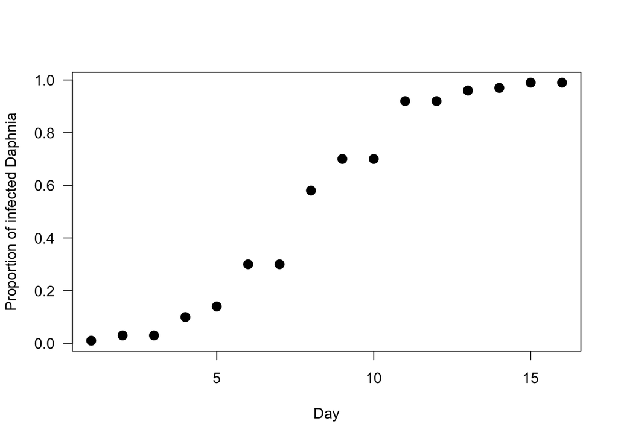

```r
daph <- c(0.01, 0.03, 0.03, 0.1, 0.14, 0.3, 0.3, 0.58, 0.7, 0.7, 0.92, 0.92, 0.96, 0.97, 0.99, 0.99)
plot(x = 1:length(daph), y = daph, las = 1, xlab = "Day", ylab = "Proportion of infected Daphnia", pch = 16, cex = 1.5)
```

### 7.7

Equation 1 is a perfectly fine representation of the accumualtion of infected individuals in the population. What equation would describe the rate of change in the number of susceptibles in the population? What would be the integrated form of that equation (think about 7.5 and single spiecies models)?

The equation would be $\frac{dS}{dt} = - \beta SI$.

Along the lines of reasoning of transforming $S$ to $N-1$ for equation 1 and 7.5, we can do the same for $\frac{dS}{dt} = - \beta SI$. We know that $N = S + I$, so $I = N - S$. Substituting that into $\frac{dS}{dt} = - \beta SI$ we arrive at $\frac{dS}{dt} = - \beta S(N - S)$. And, like in equation 1, we are working with proportions and can convert $N$ to 1. This is the same form as equation 1, which is logistic, and we can similarly integrate it
$$S_t = \frac{S_0}{(1 - S_0)\exp (\beta t) + S_0}.$$
The only major difference is that $\beta$ is now positive.

### 7.8

Begin with a very small infection ($I_0 = 0.001$) and use the integrated form of the mass action equation (7.5) to compute the time series for the susceptible (make a solid line) and infected (make a dashed line [in `plot()` or `lines()` use the argument `lty = 2`, which is abbr. for “line type”]) populations, with $\beta = 0.9$ (color the lines black), then with $\beta = 0.1$ (color the lines red). Plot susceptibles and infecteds on the same graph, but one graph for each $\beta$. (Use the same length of time over which you’re plotting, and ensure that you capture the dynamics of each.)

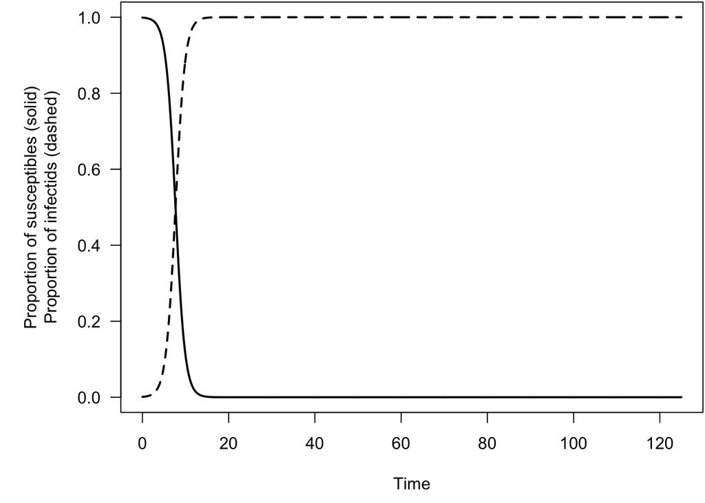

```r
I0 <- 0.001
beta_1 <- 0.9
beta_2 <- 0.1
times <- seq(from = 0, to = 125, by = 0.1)

It_1 <- I0 / ((1 - I0)*exp(-beta_1*times) + I0)
It_2 <- I0 / ((1 - I0)*exp(-beta_2*times) + I0)

St_1 <- 1 - It_1
St_2 <- 1 - It_2

par(mar = c(4.5, 6, 0.1, 0.1))
plot(x = times, y = St_1, las = 1, xlab = "Time", ylab = "Proportion of susceptibles (solid)\nProportion of infectids (dashed)", type = "l", lwd = 2, ylim = c(0, 1))
lines(x = times, y = It_1, lwd = 2, col = "black", lty = 2)
```

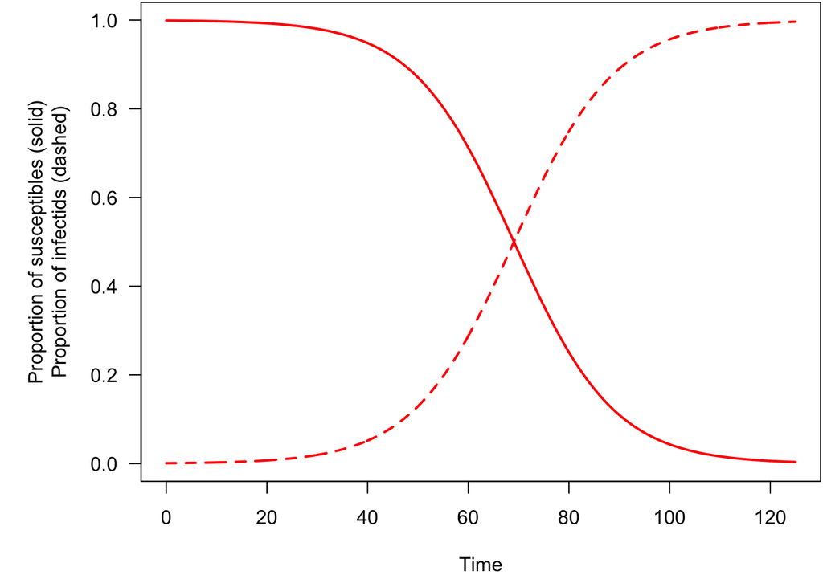

```r
plot(x = times, y = St_2, las = 1, xlab = "Time", ylab = "Proportion of susceptibles (solid)\nProportion of infectids (dashed)", type = "l", lwd = 2, ylim = c(0, 1), col = "red")
lines(x = times, y = It_2, lwd = 2, col = "red", lty = 2)
```